# Exercises Laboratory Session 06

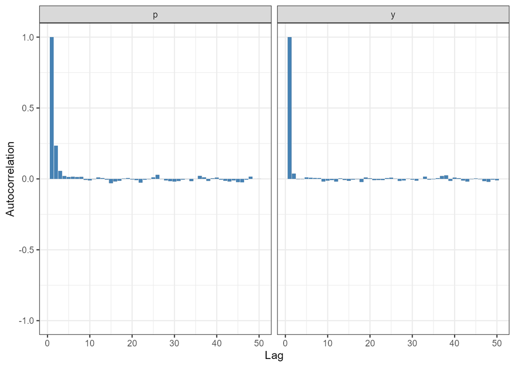

```r
chain_e6$autocorrelation()
```

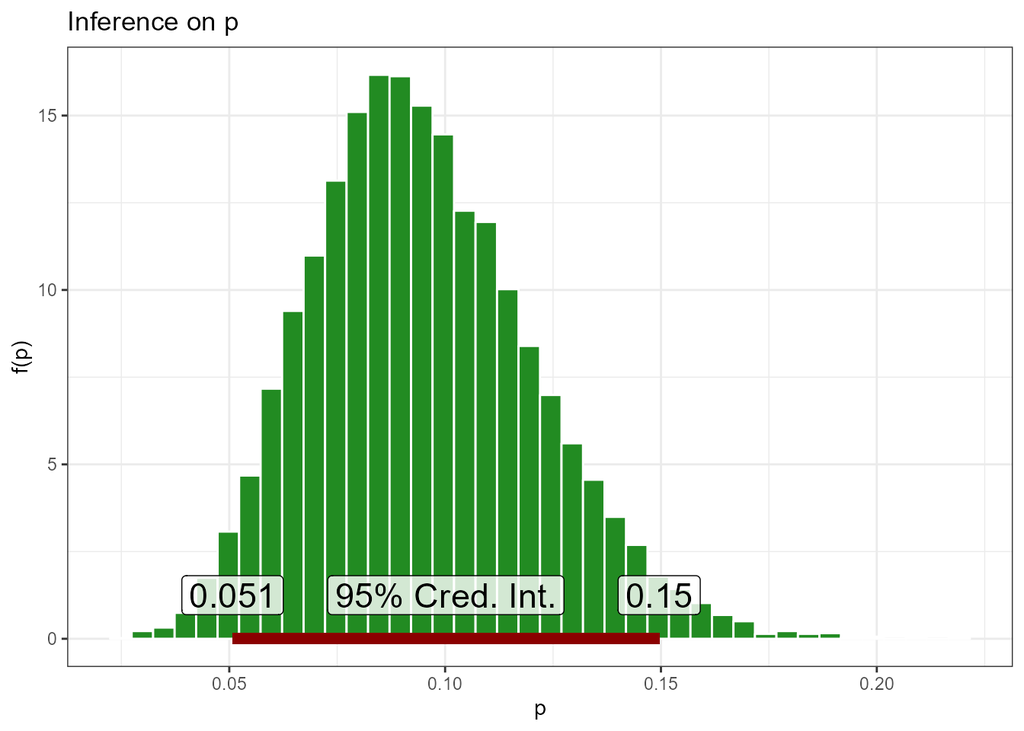

```r
chain_e6$inference(y.cred.int=1.25)
```

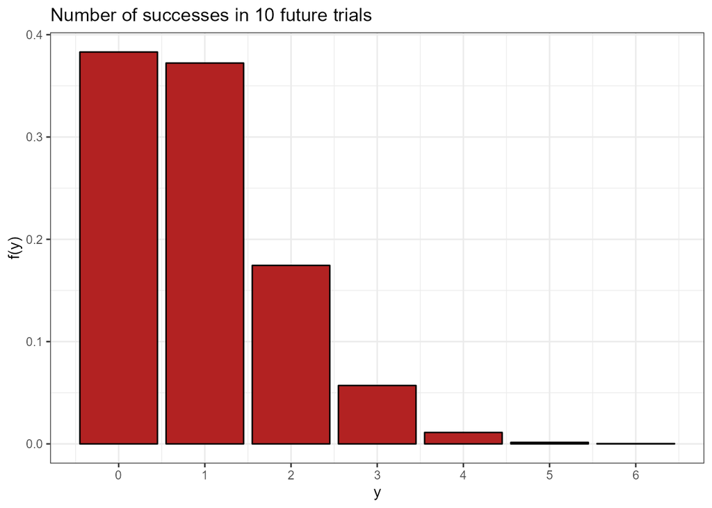

```r
chain_e6$prediction(binomial=TRUE, n.next=data$n_next)
```

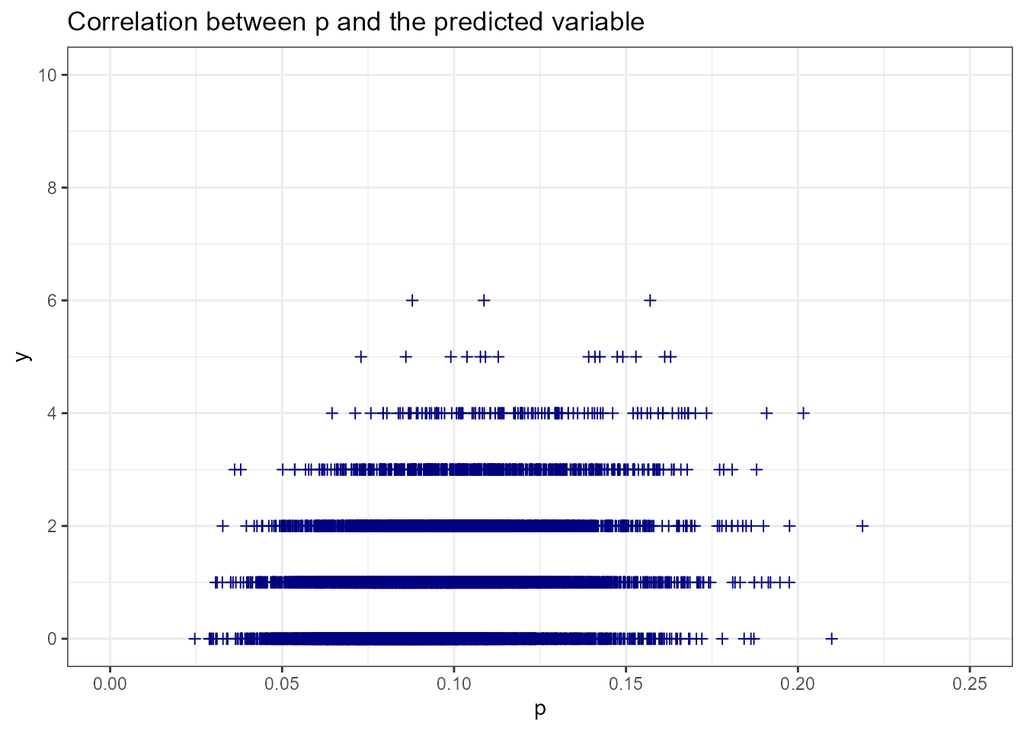

```r
chain_e6$correlation(x.min=0, x.max=0.25, y.min=0, y.max=data$n_next)
```

### Find the bayesian estimator for *p*, the posterior mean and variance, and a 95% credible interval

In the Bayesian approach, the estimator for $p$ is the posterior mean.

```r
p_estimate <- chain_e6$chain.ggs %>%
  filter(
    Parameter=='p'
  ) %>%
  summarise(
    Mean = mean(value),
    Variance = var(value)
  )

cat('Bayesian estimator for p:', p_estimate$Mean)
```

```
## Bayesian estimator for p: 0.094829
```

Notice that the bayesian estimator for $p$ found running MCMC is almost identical to the analytical result obtained in point (c) of exercise 3. The following table shows that the same is true for the other properties of the distribution, such as the variance and the credibility interval.

```r
p_estimate['Cred.Int.Low'] <- chain_e6$cred.int[1]
p_estimate['Cred.Int.High'] <- chain_e6$cred.int[2]

p_estimate %>%
  kable(caption="Results of MCMC; posterior distribution of p") %>%
  kable_styling(full_width=FALSE)
```

Results of MCMC; posterior distribution of p

| Mean | Variance | Cred.Int.Low | Cred.Int.High |
| --- | --- | --- | --- |
| 0.09483 | 0.00065 | 0.05076 | 0.14959 |

It is also possible to plot the analytical posterior above the histogram obtained running MCMC, to have a visual comparison of the 2 distributions.

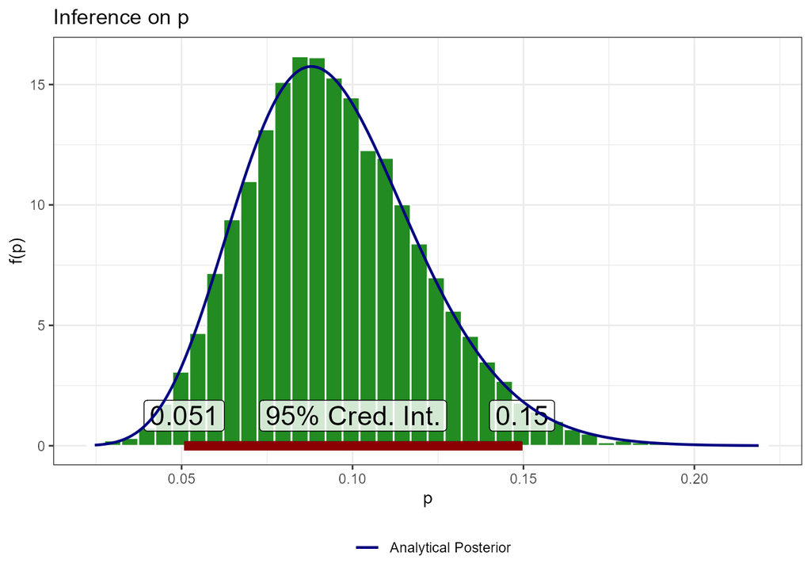

```r
tmp <- chain_e6$chain.ggs %>%
        filter(Parameter=='p') %>%
  summarise(
    min = min(value),
    max = max(value),
    len = length(value)
  )

x <- seq(tmp$min, tmp$max, length=tmp$len)

chain_e6$inference(y.cred.int=1.25) +
  geom_line(aes(x, dbeta(x, alpha.water, beta.water), color='Analytical Posterior'), size=0.8)+
  scale_color_manual('', values=c('Analytical Posterior'='navyblue'))+
  theme(legend.position='bottom')
```